# Week 6: The logic of Bayesian inference

Tristan Muno

October 14, 2026

## Week 6 goals

By the end of today, you will be able to:

1. Distinguish probability as long-run frequency from probability as degree of belief, and state the rules both share.
2. Use R to simulate random draws and compute probabilities from a distribution, and tell a probability mass function from a density.
3. Explain statistical inference as reasoning with conditional probabilities, and say what the Bayesian approach treats as fixed and what as uncertain.
4. Name the four ingredients of Bayes’ theorem, say what each does, and compute a posterior by counting.
5. Describe how the prior and the amount of data shape the posterior, why updating one observation at a time gives the same answer, and how Bayesian updating recovers falsification.
6. Explain why computing the posterior exactly becomes infeasible as parameters are added.

## Today

1. **The globe toss:** a question we cannot yet answer
2. **What probability is:** two interpretations, one set of rules
3. **Simulating probability in R:** counting simulated outcomes
4. **Counting the ways:** from tosses to Bayes’ theorem
5. **From seven conjectures to a curve:** priors, data and the dashboard
6. **Why exact computation breaks:** and what next week does about it

## Where today fits

Today is the logic behind **step 3**.

The formal model is a likelihood for the data and a prior for the unknown. Every model from week 8 onwards is this same logic with more parameters.

Table 1: The 8-step Bayesian workflow. Every homework exercises the steps introduced so far, cumulatively, and the exam runs all eight end to end.

| # | Step | What you produce |
| --- | --- | --- |
| 1 | **Estimand** | The quantity you want to learn about, stated precisely as a target before any model is fitted. |
| 2 | **Data summary** | The data described: measurement, coverage, obvious issues. |
| 3 | **Formal model** | Likelihood and priors written down, the generative model. |
| 4 | **Prior predictive check** | Simulate from the priors, confirm they imply plausible data. |
| 5 | **Fit** | Estimate with `brms`, weakly-informative priors by default. |
| 6a | **MCMC diagnostics** | R-hat, ESS, divergences, trace plots. Did sampling work? |
| 6b | **Posterior predictive check** | Does the fitted model reproduce key features of the data? |
| 7 | **Interpretation** | Answer the estimand on the outcome scale, with uncertainty. |
| 8 | **Limitations** | What the analysis can and cannot support, threats and next steps. |

# The globe toss

## Catch, look, call

1. Catch the globe.
2. Look at the spot under your right index finger.
3. Call out **water** or **land**.
4. Throw it on.

## What do we know now?

- What proportion of the Earth’s surface is water?
- How sure are you?
- Would 3 tosses have convinced you? Would 300?
- **What is the probability that more than half of the Earth is water?**
- And before the first toss: what did you already believe?
  - Probably that the Earth is neither all land nor all water.
  - And probably that more than half of it is water.

**Note**

**A belief held before the data is called a prior.** It is uncertain, and it has a shape: some proportions of water seem more plausible than others, and some seem ruled out. Today we write such beliefs down as probability distributions and work out how data change them.

# What is probability?

## Two interpretations

**Long-run frequency**

The share of favourable outcomes when a process is repeated many times.

$$P(A) = \lim_{n \to \infty} \frac{\text{count}(A)}{n}
\tag{1}$$

- A property of a repeatable process.
- Natural for coins, dice and random samples.

**Degree of belief**

How plausible a proposition is to an agent, given the information $I$ the agent has.

$$P(A \mid I)
\tag{2}$$

- A property of a state of knowledge.
- Applies to one-off events, parameters and hypotheses.

There is only one Earth, so “the probability that more than half the Earth is water” is a one-off question. It needs the second reading.

## The rules both share

Whatever probability *means*, it obeys the same rules.

- Every probability lies **between 0 and 1**: $0 \leq P(A) \leq 1$.
- 0 means impossible, 1 means certain, and everything in between is graded.
- The probabilities of all possible outcomes **add up to 1**. For a continuous quantity, the **area under the density** is 1.

$$\sum_{k} P(X = k) = 1 \qquad \int p(x) \, dx = 1
\tag{3}$$

**Important**

**A probability can take any value from 0 to 1.** A probability is a graded statement. That is exactly what lets us say a hypothesis is “0.9 probable”.

## Inference is conditional

Week 1: separate **signal** from **noise**.

That is the fundamental task of statistics.

Every way of doing that is a statement about a **conditional probability**, read “given”:

$$P(A \mid B) = \text{the probability of } A \text{, given that } B \text{ holds}
\tag{4}$$

The two schools of inference ask the same question in two directions. What goes to the right of the bar, and what to the left, is the whole difference.

## Fixed or uncertain?

Table 2: Two schools of inference and what each treats as fixed.

|  | Frequentist inference | Bayesian inference |
| --- | --- | --- |
| The parameter $\theta$ | A fixed, unknown constant | Uncertain, so it gets a probability distribution |
| The data | One random draw from many hypothetical repetitions | Observed, so fixed once seen |
| The question | How surprising are data like these, if $\theta$ had a given value? | How plausible is each value of $\theta$, given the data? |
| In notation | $P(\text{data} \mid \theta)$ | $P(\theta \mid \text{data})$ |
| A typical answer | A p-value | $P(\theta > 0.5 \mid \text{data})$ |

**Note**

**A p-value is a statement about data, given a hypothesis.** It is the probability, computed as if the null hypothesis held, of a test statistic at least as extreme as the one from our data.

## The central idea

The tosses happened.

They are facts, and we condition on them.

The proportion of water $\theta$ has one true value, but **we do not know it**. Our uncertainty about it has structure: some values are more plausible than others.

A probability distribution over $\theta$ describes **what we know** about $\theta$. Learning from data means that distribution changes as the data come in.

$$P(\theta \mid \text{data})
\tag{5}$$

**Note**

**Read Equation 5 as “the probability of the parameter $\theta$, given the observed data”.**

# Simulating probability in R

## The r, d, p, q functions

Four functions per distribution.

A prefix says which one you get.

Table 3: The four distribution functions in R, with everyday examples. The arguments are, in order, the value, then size and prob for the binomial, mean and sd for the normal.

| Prefix | Gives | In words | Binomial: coin flips | Normal: height (mean 170 cm, sd 10 cm) |
| --- | --- | --- | --- | --- |
| `r` | **r**andom draws | Simulate the process | `rbinom(10, 1, 0.5)`: ten flips, 1 is heads | `rnorm(5, 170, 10)`: five heights |
| `d` | mass or **d**ensity | Probability of exactly this value, or the density there | `dbinom(6, 10, 0.5)`: 0.205 for exactly 6 heads in 10 | `dnorm(180, 170, 10)`: 0.024, the density at 180 cm |
| `p` | cumulative **p**robability | Probability of this value or less | `pbinom(3, 10, 0.5)`: 0.172 for 3 heads or fewer | `pnorm(160, 170, 10)`: 0.159 of people are below 160 cm |
| `q` | **q**uantile | The value below which a given share lies | `qbinom(0.5, 10, 0.5)`: 5 heads is the median | `qnorm(0.9, 170, 10)`: 90 percent are below 182.8 cm |

The globe toss is a **binomial** process: $N$ tosses, each water with probability $\theta$.

## The long run

Simulation can **test a claim about probability**.

After how many tosses is the share of water close to the true 0.71?

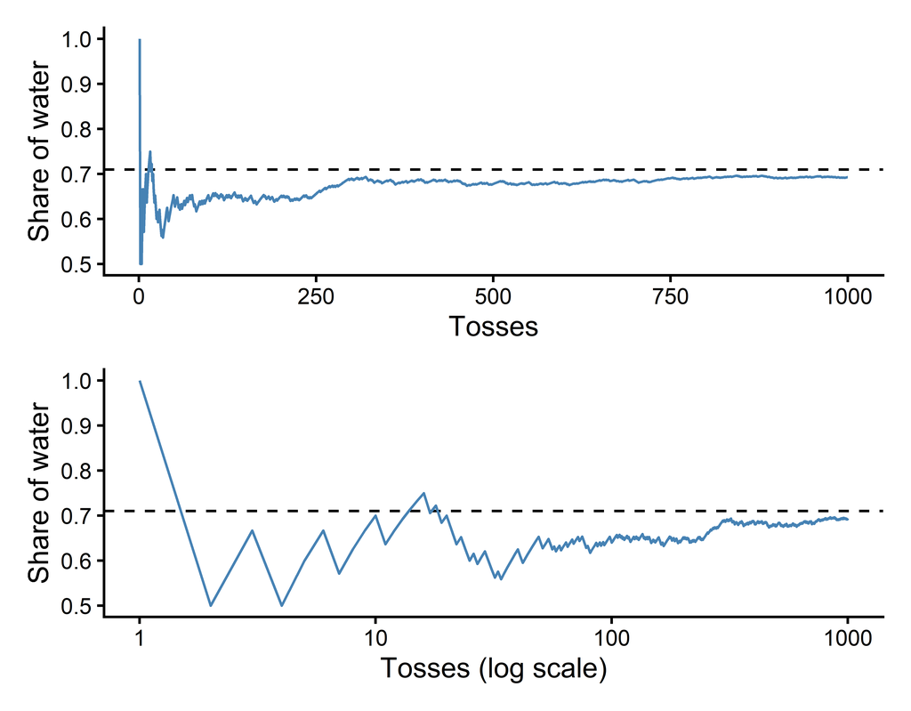

Figure 1: The share of water in 1000 simulated tosses, on an ordinary and a log axis (true value dashed). Each extra toss helps less than the one before.

```r
set.seed(3594)
tosses <- rbinom(1000, size = 1, prob = 0.71)

long_run <- tibble(
  n = 1:1000,
  share = cummean(tosses) # share of water so far
) |>
  ggplot(aes(x = n, y = share)) +
  geom_hline(yintercept = 0.71, linetype = "dashed") +
  geom_line(colour = "steelblue") +
  theme_classic() +
  labs(x = "Tosses", y = "Share of water")

# The same plot again, with a log x-axis.
long_run / (long_run + scale_x_log10() + labs(x = "Tosses (log scale)"))
```

## Probability of a count

`dbinom()` gives the probability of each count.

**How probable is each number of water tosses in 15?**

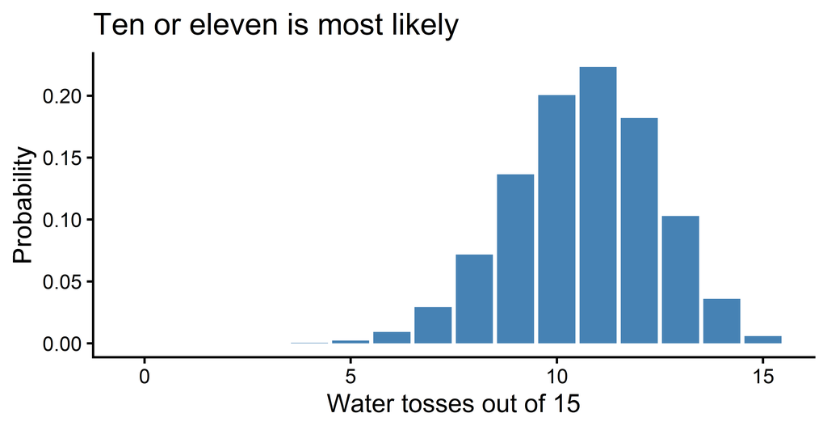

Figure 2: Water tosses out of 15 when theta is 0.71. Each bar is a probability, and the 16 bars add up to 1.

```r
tibble(water = 0:15) |>
  mutate(prob = dbinom(water, size = 15, prob = 0.71)) |>
  ggplot(aes(x = water, y = prob)) +
  geom_col(fill = "steelblue") +
  theme_classic() +
  labs(
    x = "Water tosses out of 15",
    y = "Probability",
    title = "Ten or eleven is most likely"
  )
```

```r
sum(dbinom(0:15, size = 15, prob = 0.71))
```

```
[1] 1
```

A count is **discrete**, so each outcome gets a probability: a **probability mass function**.

## A density

Height is continuous: nobody is exactly 170.000 cm tall.

A continuous quantity has infinitely many values, so a single exact value has probability 0. A **density** has the same job as the bars of a probability mass function, but for a continuous quantity: it shows where values are concentrated, and **probability is the area** under it.

**View source**

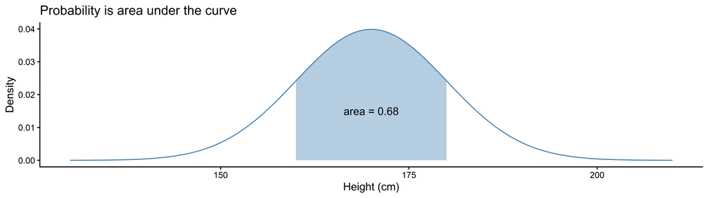

Figure 3: The density of adult height, normal with mean 170 cm and standard deviation 10 cm. The shaded area between 160 and 180 cm is the probability that a person’s height falls in that range, about 0.68.

```r
tibble(height = seq(130, 210, by = 0.5)) |>
  mutate(density = dnorm(height, mean = 170, sd = 10)) |>
  ggplot(aes(x = height, y = density)) +
  geom_area(
    data = \(d) filter(d, height >= 160, height <= 180),
    fill = "steelblue",
    alpha = 0.4
  ) +
  geom_line(colour = "steelblue") +
  annotate("text", x = 170, y = 0.015, label = "area = 0.68") +
  theme_classic() +
  labs(
    x = "Height (cm)",
    y = "Density",
    title = "Probability is area under the curve"
  )
```

## Density values and areas

`dnorm()` gives the height of the curve, `pnorm()` gives an area.

```r
dnorm(170, mean = 170, sd = 10) # density at 170 cm
```

```
[1] 0.03989423
```

```r
dnorm(1.70, mean = 1.70, sd = 0.10) # the same, in metres
```

```
[1] 3.989423
```

```r
pnorm(180, mean = 170, sd = 10) - pnorm(160, mean = 170, sd = 10) # area: a probability
```

```
[1] 0.6826895
```

**Warning**

**Probabilities are areas under the density, so they always lie between 0 and 1.** A density value is the height of the curve, and it depends on the units: in metres the same heights have a density of almost 4. The 95 percent from week 1 is the area `pnorm(2) - pnorm(-2)`.

## Practice: counting

**Do this now.**

1. Simulate 15 tosses of a globe that is 71 percent water. Compare with our tally on the board.
2. What is the probability of 10 or more water tosses in 15? Compute it with `dbinom()`, then by simulating 10,000 rounds of 15 tosses and counting.
3. What share of a standard normal lies within one standard deviation of the mean?
4. **Stretch:** what is the most likely number of water tosses in 150?

**Tip**

**Start with `set.seed(3594)`.** R’s random numbers come from a generator, and `set.seed()` fixes its starting point. The same code then gives the same draws on every run and on every laptop, so results are reproducible. The number itself is arbitrary, but avoid common picks like `1234`, `42` or the current year, because everyone who uses them gets the same “random” draws. For a truly random seed, draw one at [random.org](https://www.random.org/), and read Heiss (2026) for why it matters.

## Practice: solution

```r
# Fix the generator's starting point, so these draws are reproducible.
set.seed(3594)

# 1. Draw 15 random values, each the outcome of 1 toss (size = 1)
#    that comes up water (1) with probability 0.71.
rbinom(15, size = 1, prob = 0.71)
```

```
 [1] 1 0 1 0 1 1 0 1 1 1 0 1 1 1 1
```

```r
# 2a. The probability of exactly 10, 11, ..., 15 water in 15 tosses, added up.
sum(dbinom(10:15, size = 15, prob = 0.71))
```

```
[1] 0.7504792
```

```r
# 2b. Simulate 10,000 rounds of 15 tosses, each giving a count of water.
#     ">= 10" marks each round TRUE or FALSE, and mean() is the share of TRUE.
mean(rbinom(1e4, size = 15, prob = 0.71) >= 10)
```

```
[1] 0.7496
```

## Practice: solution, continued

```r
# 3. The area of a standard normal below 1, minus the area below -1,
#    leaves the area between -1 and 1.
pnorm(1) - pnorm(-1)
```

```
[1] 0.6826895
```

```r
# 4. The probability of each count from 0 to 150, then the position of the largest.
#    Positions start at 1 and counts at 0, so subtract 1.
which.max(dbinom(0:150, size = 150, prob = 0.71)) - 1
```

```
[1] 107
```

Counting simulated outcomes approximates the probability, and more simulations approximate it better. Next week this idea carries the whole of Bayesian computation.

# Counting the ways

## A globe with six faces

Imagine the Earth as a **six-faced die**.

Each face is water or land. The unknown $\theta$ is the share of water faces, so there are exactly **seven conjectures**:

$$\theta \in \left\{ \tfrac{0}{6}, \tfrac{1}{6}, \tfrac{2}{6}, \tfrac{3}{6}, \tfrac{4}{6}, \tfrac{5}{6}, \tfrac{6}{6} \right\}
\tag{6}$$

The plan is the one from week 1: statistics is counting. For each conjecture, **count the ways it could have produced the tosses we saw**. A conjecture with more ways is more plausible (McElreath 2020).

## Counting paths

Take the first three tosses: **W L W**.

Now take the conjecture with 4 water faces. The first toss can land on any of 4 water faces, the second on any of 2 land faces, the third on any of 4 water faces again.

$$4 \times 2 \times 4 = 32 \text{ ways}
\tag{7}$$

With $k$ water faces, W L W can happen in $k \times (6 - k) \times k$ ways.

Table 4: Ways each conjecture produces W L W.

| Water faces $k$ | 0 | 1 | 2 | 3 | 4 | 5 | 6 |
| --- | --- | --- | --- | --- | --- | --- | --- |
| Ways to see W L W | 0 | 5 | 16 | 27 | 32 | 25 | 0 |

**Tip**

**Check a row in R.** `dbinom(2, size = 3, prob = 4/6)` is $3 \times 32 / 6^3$, so the counts are proportional to the binomial probabilities.

## Ruled out for good

Look at the ends of Table 4.

The first **W** gives the all-land globe ($k = 0$) **zero ways**, and the **L** does the same for the all-water globe ($k = 6$). Every later count is multiplied onto that zero, so those two conjectures stay ruled out for good.

$$P(\theta = 0 \mid \text{W L W}) = \frac{P(\text{W L W} \mid \theta = 0) \, P(\theta = 0)}{P(\text{W L W})} = \frac{0 \times P(\theta = 0)}{P(\text{W L W})} = 0
\tag{8}$$

This is **falsification** (Popper 1959): one observation can rule a conjecture out for good, while every confirmation only raises its plausibility a little. In Bayesian updating it is the special case of a **zero likelihood**.

**Note**

**Real refutations are usually softer.** Measurements can be wrong, so an observation that a hypothesis forbids usually has a tiny likelihood under it. The hypothesis then keeps only a tiny share of its plausibility.

## A new toss: multiply

The fourth toss is **W**.

With $k$ water faces it can happen in $k$ ways, so multiply.

Table 5: Sequential updating by counting. The old counts are multiplied by the ways the new toss could happen.

| Water faces $k$ | Ways for W L W | Ways for the new W | Updated ways |
| --- | --- | --- | --- |
| 0 | 0 | 0 | 0 |
| 1 | 5 | 1 | 5 |
| 2 | 16 | 2 | 32 |
| 3 | 27 | 3 | 81 |
| 4 | 32 | 4 | 128 |
| 5 | 25 | 5 | 125 |
| 6 | 0 | 6 | 0 |

- **Yesterday’s counts are today’s prior.**
- Multiplication does not care about order, so updating toss by toss gives the same answer as counting all four at once.

## The four ingredients

Divide each count by the sum.

That turns counts into probabilities. Here with W L W, and every conjecture equally plausible beforehand.

Table 6: From counts to a posterior. Each row of prior times ways is divided by their sum, 105, so the posterior adds up to 1.

| $k$ | Prior | Ways (likelihood) | Prior times ways | Posterior |
| --- | --- | --- | --- | --- |
| 0 | 1 | 0 | 0 | 0.000 |
| 1 | 1 | 5 | 5 | 0.048 |
| 2 | 1 | 16 | 16 | 0.152 |
| 3 | 1 | 27 | 27 | 0.257 |
| 4 | 1 | 32 | 32 | 0.305 |
| 5 | 1 | 25 | 25 | 0.238 |
| 6 | 1 | 0 | 0 | 0.000 |
|  |  |  | **Sum: 105** | **Sum: 1** |

## Naming the ingredients

Each column of Table 6 is one ingredient.

1. **Prior**: plausibility before the data.
2. **Likelihood**: the ways the data could arise under each conjecture.
3. **Normalising constant**: the sum, every way the data could have been produced.
4. **Posterior**: plausibility after the data, now a proper probability distribution.

## Bayes’ theorem

The table is Bayes’ theorem, one column at a time.

$$\underbrace{P(\theta \mid \text{data})}_{\text{posterior}} = \frac{\overbrace{P(\text{data} \mid \theta)}^{\text{likelihood}} \; \overbrace{P(\theta)}^{\text{prior}}}{\underbrace{P(\text{data})}_{\text{normalising constant}}}
\tag{9}$$

The normalising constant sums the numerator over every conjecture:

$$P(\text{data}) = \sum_{\theta} P(\text{data} \mid \theta) \, P(\theta)
\tag{10}$$

It is the same number for every $\theta$. Its only job is to make the posterior add up to 1.

## All fifteen tosses

Fifteen tosses, 10 of them water.

The likelihood is binomial, so `dbinom()` computes it.

**View source**

```r
globe <- tibble(water_faces = 0:6) |>
  mutate(
    theta = water_faces / 6,
    prior = 1 / 7,
    likelihood = dbinom(example_w, size = example_n, prob = theta),
    posterior = prior * likelihood / sum(prior * likelihood)
  )

globe |>
  kable(digits = 3)
```

Table 7: The six-faced globe after 10 water tosses in 15, from a flat prior. The likelihood column is the probability of the data under each conjecture, the posterior is prior times likelihood divided by their sum.

| water_faces | theta | prior | likelihood | posterior |
| --- | --- | --- | --- | --- |
| 0 | 0.000 | 0.143 | 0.000 | 0.000 |
| 1 | 0.167 | 0.143 | 0.000 | 0.000 |
| 2 | 0.333 | 0.143 | 0.007 | 0.018 |
| 3 | 0.500 | 0.143 | 0.092 | 0.244 |
| 4 | 0.667 | 0.143 | 0.214 | 0.571 |
| 5 | 0.833 | 0.143 | 0.062 | 0.166 |
| 6 | 1.000 | 0.143 | 0.000 | 0.000 |

The likelihood column adds up to 0.375. The likelihood **scores how well each conjecture fits the data**, and the normalising constant turns those scores into a distribution.

# From seven conjectures to a curve

## A finer globe

A real globe has far more than six faces.

More faces mean more conjectures, and the bars fill in a curve.

**View source**

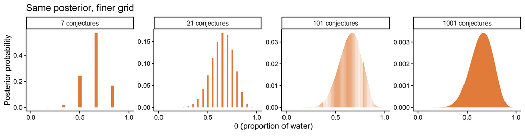

Figure 4: The posterior for the proportion of water after 10 water tosses in 15, from a flat prior, computed on grids of 7, 21, 101 and 1001 conjectures. As the grid gets finer, the bars approach a smooth curve over every value between 0 and 1.

```r
grid_posterior <- function(points) {
  tibble(theta = seq(0, 1, length.out = points)) |>
    mutate(
      likelihood = dbinom(example_w, size = example_n, prob = theta),
      posterior = likelihood / sum(likelihood),
      grid = paste(points, "conjectures"),
      width = case_when(points <= 7 ~ 2, points <= 21 ~ 1, .default = 0.3)
    )
}

c(7, 21, 101, 1001) |>
  map(grid_posterior) |>
  list_rbind() |>
  mutate(grid = fct_inorder(grid)) |>
  ggplot(aes(x = theta, y = posterior)) +
  geom_segment(aes(xend = theta, yend = 0, linewidth = width), colour = col_2) +
  scale_linewidth_identity() +
  facet_wrap(~grid, nrow = 1, scales = "free_y") +
  scale_x_continuous(breaks = c(0, 0.5, 1)) +
  theme_classic() +
  labs(
    x = expression(theta ~ "(proportion of water)"),
    y = "Posterior probability",
    title = "Same posterior, finer grid"
  )
```

## The dashboard

Experiment with the **interactive dashboard** on the next slide:

- Pick a **prior**: uniform, weakly informative, informative or dogmatic, then move $\alpha$ and $\beta$.
- Set the **data**: a simulated globe with a true $\theta$ and up to 1000 tosses, starting from 10 water in 15.
- Watch the **prior**, the **likelihood** and the **posterior**, computed on a grid of 1000 conjectures.

Three rounds. **Predict first, then move the control.**

1. The defaults, uniform prior, then informative prior. Where does the posterior sit?
2. Weakly informative prior, tosses from 1 to 1000. What happens to the prior’s influence?
3. Dogmatic prior, true $\theta$ 0.71, 1000 tosses. Where is the posterior now?

## Try it

[interactive chart not shown]

Figure 5: Prior, likelihood and posterior for the proportion of water.

[interactive chart not shown]

## Prior versus data

**View source**

```r
set.seed(3594)
sim_tosses <- rbinom(1000, size = 1, prob = 0.71)

priors <- tibble(
  prior = c("Weak", "Informative", "Dogmatic"),
  a = c(2, 14, 500),
  b = c(2, 6, 500)
)

expand_grid(priors, tosses = c(15, 150, 1000), theta = (1:999) / 1000) |>
  mutate(
    water = map_dbl(tosses, \(n) sum(sim_tosses[1:n])),
    prior_density = dbeta(theta, a, b),
    unnormalised = prior_density * dbinom(water, size = tosses, prob = theta)
  ) |>
  group_by(prior, tosses) |>
  mutate(posterior_density = unnormalised / sum(unnormalised) * 1000) |>
  ungroup() |>
  mutate(
    prior = fct_inorder(prior),
    tosses = paste(tosses, "tosses") |> fct_inorder()
  ) |>
  ggplot(aes(x = theta)) +
  geom_vline(xintercept = 0.71, colour = "grey60") +
  geom_line(aes(y = prior_density), colour = col_1, linetype = "dashed") +
  geom_line(aes(y = posterior_density), colour = col_2) +
  facet_grid(prior ~ tosses, scales = "free_y") +
  scale_x_continuous(breaks = c(0, 0.5, 1)) +
  theme_classic() +
  labs(
    x = expression(theta ~ "(proportion of water)"),
    y = "Density",
    title = "Data pull every open-minded prior to the truth"
  )
```

[figure not shown]

Figure 6: Prior (dashed) and posterior (solid) for three Beta priors, weak Beta(2, 2), informative Beta(14, 6) and dogmatic Beta(500, 500), and growing amounts of simulated data from a globe that is 71 percent water (vertical line). With 15 tosses the prior matters a lot, with 1000 tosses the weakly informative and informative priors agree, and the dogmatic prior has still not reached the truth.

## Zero never learns

Ruling out, the other way round.

If the prior says a value is **impossible**, the posterior agrees, whatever the data:

$$P(\theta) = 0 \quad \Rightarrow \quad P(\theta \mid \text{data}) = \frac{P(\text{data} \mid \theta) \times 0}{P(\text{data})} = 0
\tag{11}$$

- **A zero likelihood** is falsification: the data rule a conjecture out.
- **A zero prior** is dogma: you ruled it out before looking.
- **A near-dogmatic prior** moves only under overwhelming data.

**Important**

**Cromwell’s rule: never give exactly 0 or 1 to anything that is not logically impossible or certain (Lindley 1985).** It is why it is so hard to change the mind of someone who is completely sure. Bayes describes how a coherent learner should update.

## The opening question

A flat prior and the example sequence.

With 10 water in 15 tosses:

$$P(\theta > 0.5 \mid \text{data}) \approx 0.895
\tag{12}$$

**Note**

**In words: given our data, the model and a flat prior, the probability that more than half of the Earth is water is about 89 percent.** Equally: given our measurements, we can be about 89 percent certain that the true proportion of water is greater than 0.5.

- A **graded statement about the hypothesis itself**.
- It holds given the data, the model and the prior, all three written down.

# Why exact computation breaks

## Why grids explode

The sum runs over **every** parameter value.

The normalising constant adds prior times likelihood for each combination of parameter values. With $g$ grid points per parameter and $k$ parameters, that is $g^k$ terms.

Table 8: Grid size grows exponentially in the number of parameters. The observable universe holds about 10^80 atoms.

| Model | Parameters $k$ | Terms with 1000 points each |
| --- | --- | --- |
| The globe | 1 | $10^{3}$ |
| A linear regression ($\alpha$, $\beta$, $\sigma$) | 3 | $10^{9}$ |
| A regression with 10 predictors | 12 | $10^{36}$ |
| A modest multilevel model | 50 | $10^{150}$ |

**Note**

**The cost grows exponentially with the number of parameters.** The paths the tosses could take grow as $6^N$ too, and the binomial formula counts them all in one step. The sum over parameters has such a shortcut only in a few special models.

## Next week

**Markov chain Monte Carlo**

- Instead of computing the posterior everywhere, **draw samples** from it.
- The normalising constant is never computed at all.
- Counting samples replaces counting ways, as in today’s R practice.

# Wrap-up

## Summary

Six things to keep.

- **Two notions of probability**, frequency and degree of belief, with the same rules.
- **Two schools of inference**, the same goal of separating signal from noise, and a different answer to what is fixed and what is uncertain.
- **Four ingredients**: prior, likelihood, normalising constant, posterior. Prior and likelihood together set where the posterior sits and how wide it is.
- **Updating is sequential**, and more data pull every open-minded prior towards the truth.
- **Falsification** is a zero likelihood, **dogma** a zero prior.
- **Exact posteriors explode** with the number of parameters, so next week we sample.

## Homework

One homework this week.

- `hw-06`: today’s updating logic, applied to a new question, due 21 October. Linked from the Schedule.
- A sample solution is published after the due date.

**Important**

**Individual feedback is only available through the opt-in path.** Add an open-source `license.md` to your submission repo to opt in.

## References

Heiss, Andrew. 2026. “Generating Universes Within Universes with a Single Seed.” April 13. https://doi.org/10.59350/1z4vr-nss70.

Lindley, Dennis V. 1985. *Making Decisions*. 2nd ed. Wiley.

McElreath, Richard. 2020. “Small Worlds and Large Worlds.” In *Statistical Rethinking: A Bayesian Course with Examples in r and STAN*, 2nd ed. Chapman; Hall/CRC. https://doi.org/10.1201/9780429029608.

Popper, Karl R. 1959. *The Logic of Scientific Discovery*. Hutchinson.

# Appendix

## Where Bayes comes from

Bayes’ theorem follows from the product rule of probability, which holds under both interpretations.

$$P(A \text{ and } B) = P(A \mid B) \, P(B) = P(B \mid A) \, P(A)
\tag{13}$$

Divide both sides by $P(B)$:

$$P(A \mid B) = \frac{P(B \mid A) \, P(A)}{P(B)}
\tag{14}$$

With $A = \theta$ and $B = \text{data}$, this is Equation 9. Inference becomes Bayesian when the theorem is applied to a parameter.